# Innehållsanalys och länkanalys av #svpol

Peter M. Dahlgren

11 maj 2017

En kort analys av innehållet på #svpol samt vilka länkar som delas.

## Data

Baserat på 733998 länkar extraherade från 3109030 tweets.

Från 2015-11-19 09:54:40 till 2017-04-14 01:59:01 (totalt 512 dagar). Dock verkar inte alla länkar vara med p.g.a. tar tid att plocka ut länkarna från bit.ly och liknande tjänster som förkortar länkar.

Några analyserar visar endast april månad p.g.a. för lite datorminne för att bearbeta allt.

## Översikt

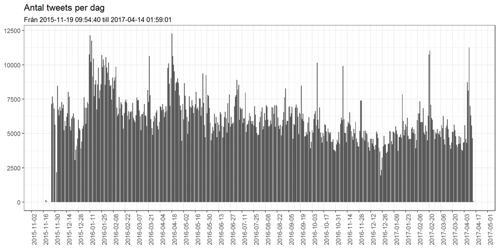

## Vanligaste orden

Stoppord (“att”, “och”, “så” etc) bortplockade på både svenska och engelska.

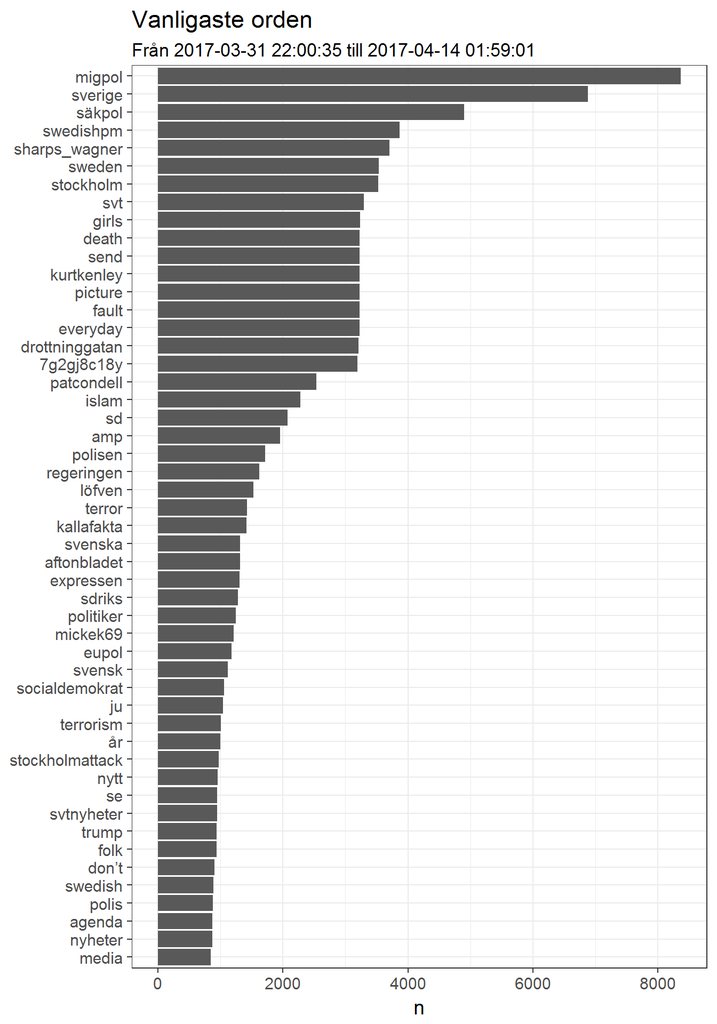

## Sentiment per timme

Förhållandet mellan positiva och negativa ord med svensk respektive engelsk sentimentordlista.

Man får dramatiskt olika resultat: överväldigande positivt på svenska, överväldigande negativt på engelska. Detta är delvis en effekt av de valda ordlistorna.

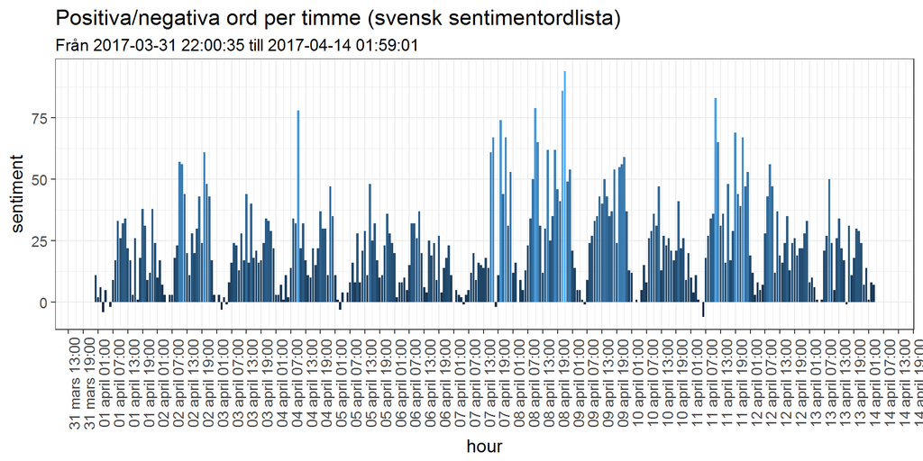

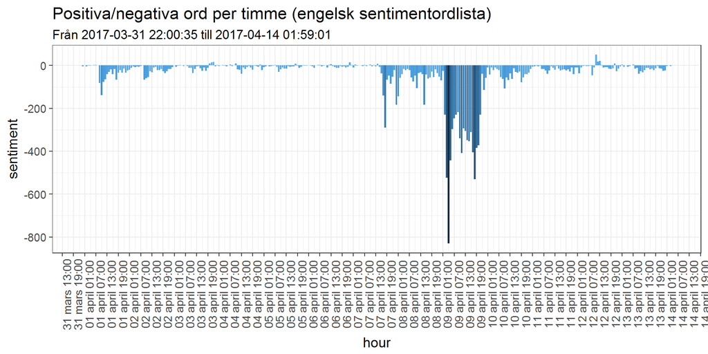

## Ordmoln

Mest förekommande orden. April månad.

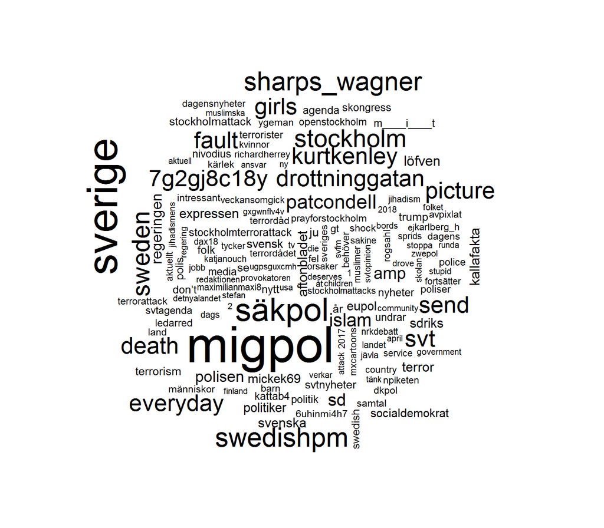

Svensk sentiment. April månad.

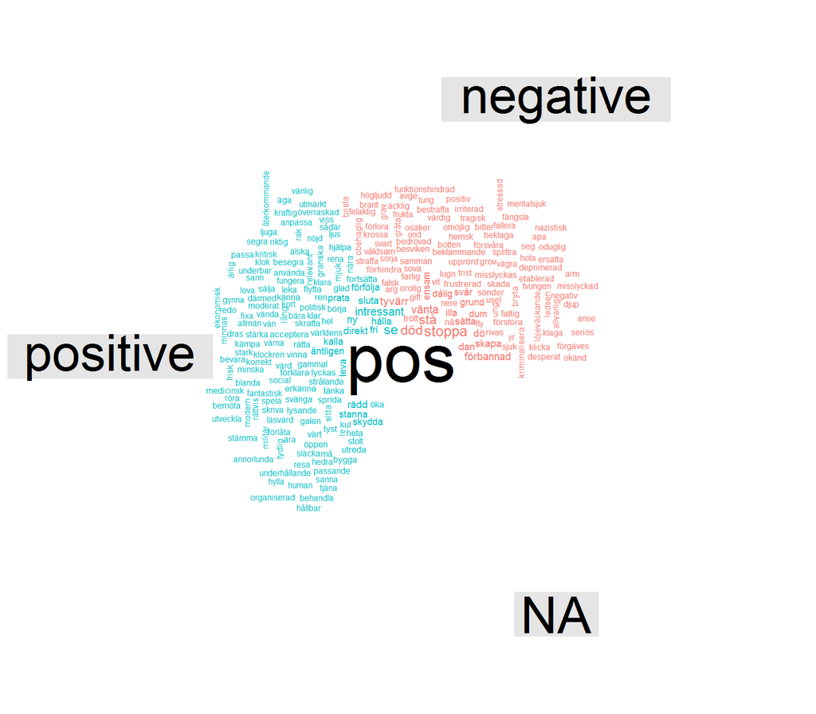

Engelsk sentiment. April månad.

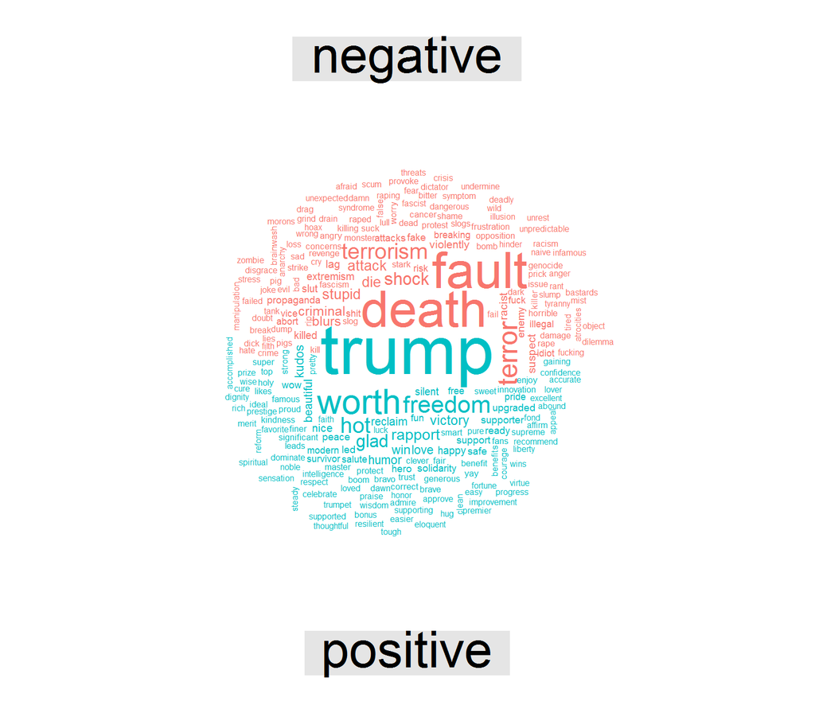

## Toppdomäner

Baserat på all tillgänglig data.

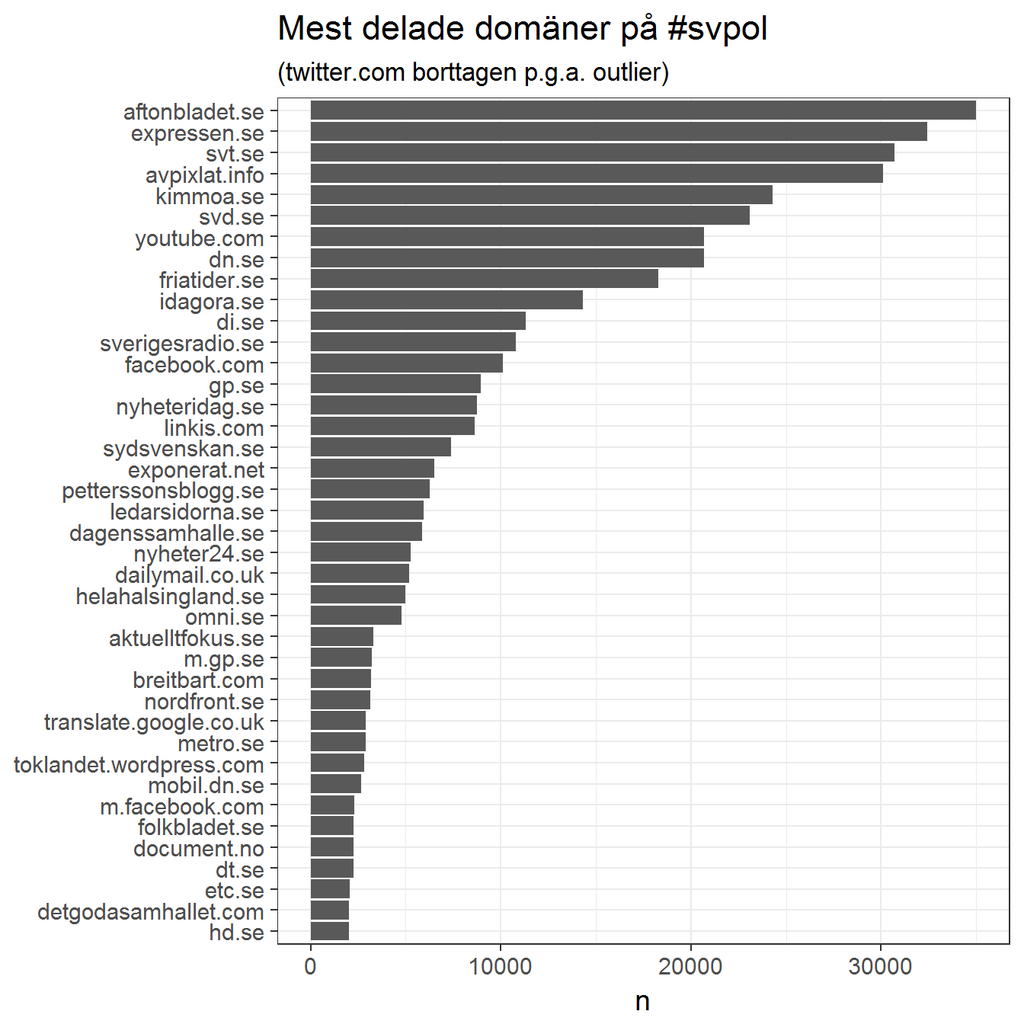

## Toppanvändare

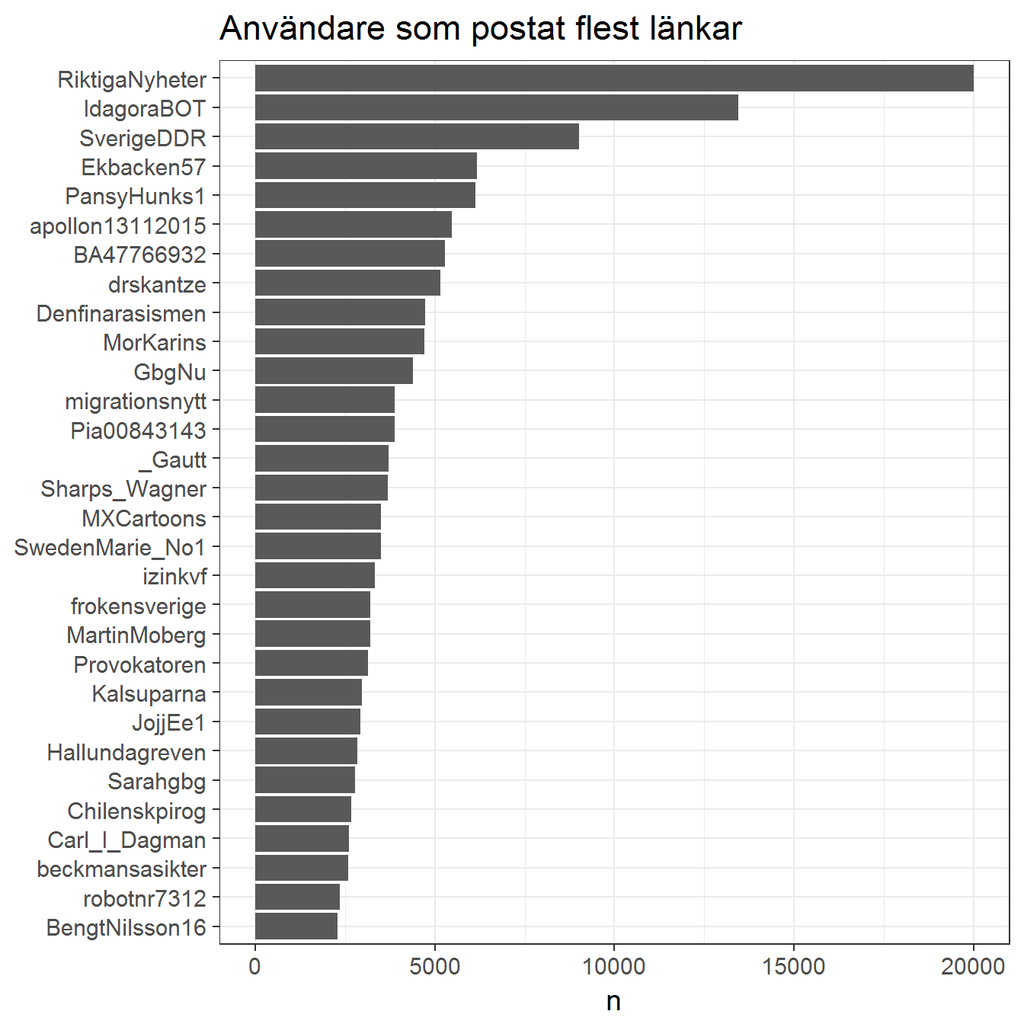

## Vem är RiktigaNyheter?

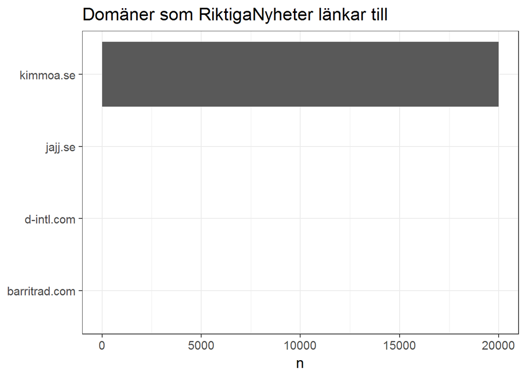

## Domännätverk

Hur många gånger två domäner förekommer tillsammans bland en och samma användare (co-occurrences). Ju grövre tjocklek på linjen, desto fler gånger har domänerna förekommit tillsammans. Samma metod som Kate Starbird har använt (se [Information Wars: A Window into the Alternative Media Ecosystem](https://medium.com/hci-design-at-uw/information-wars-a-window-into-the-alternative-media-ecosystem-a1347f32fd8f)).

Notera: Domänerna behöver inte ha förekommit i samma tweet av användaren, utan kan ha förekommit i två oberoende tweets från samma användare.

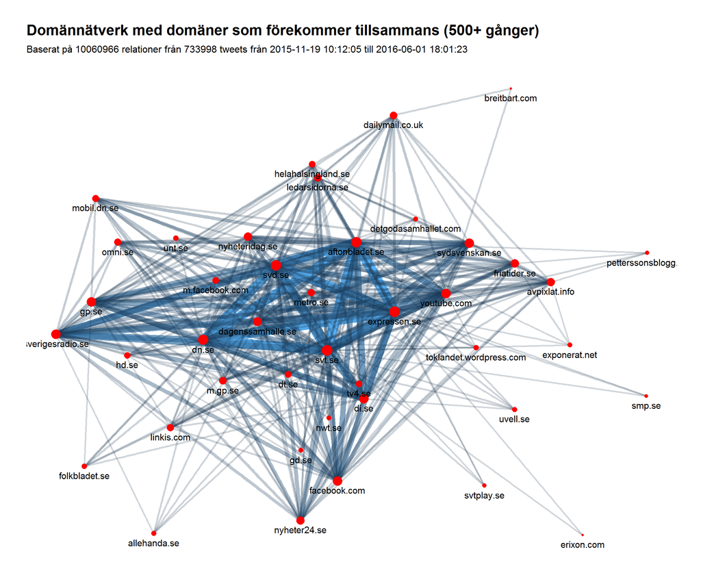

Samma sak en gång till, fast 1 000 co-occurrences som godtycklig gräns i stället för att göra nätverket lite mer lättöverskådligt. Som synes förekommer länkar till kvintetten Expressen, Aftonbladet, SVT, DN och SvD mest tillsammans.

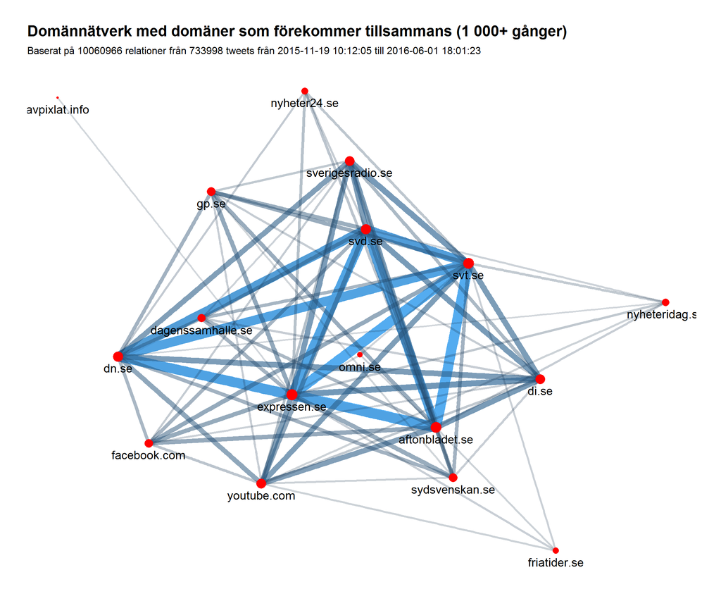

Vilken domän har flest inlänkar i nätverket?

```
## [1] "expressen.se"
```